# Phase 1 — Descriptive Demography and Exposure Validation

Heat Stress and Perinatal Outcomes in the Navrongo HDSS (Chapter 3)

Vincent

18 June 2026

# 1 Purpose and scope

This document opens Phase 1 of the analytic plan. Before any descriptive demography of the outcomes, it **validates the exposure construction** produced by `02_link_era5_utci.Rmd` against three substantive checks that a correct daily-maximum UTCI series for the Kassena-Nankana catchment must pass:

- **Seasonal pattern** — daily-max UTCI should peak in the hot-dry season (roughly March–May) and trough in the wet monsoon (July–August), with a secondary dip in the dry-cool harmattan. A series that is flat across months is a red flag (it was the signature of the earlier MRT-inflation bug); a series with a clear pre-monsoon hump is the expected Sahelian climatology.
- **Spatial pattern** — within a catchment this small (a few 0.25° grid cells), between-location variation in the daily-max distribution should be modest. Large spatial scatter would indicate a coordinate or grid-matching problem.
- **Year-on-year trend** — the annual mean of daily-max UTCI should show a gentle upward drift consistent with the regional warming signal over 1995–2020, without implausible jumps that would signal a data-version or unit discontinuity.

These checks belong here, in the descriptive phase, rather than in the linkage script, whose job is only to build the exposure matrix. Passing them is the precondition for trusting `exposure.rds` as the input to the Phase 3 DLNM.

The remainder of the document then proceeds to the descriptive demography of the analytic cohort (outcome rates, birth weight, and covariate distributions). Those sections are scaffolded here and will be completed as the outcome-modelling phases come online.

```r
suppressPackageStartupMessages({
  library(dplyr)
  library(tidyr)
  library(lubridate)
  library(readr)
  library(stringr)
  library(ggplot2)
  library(scales)
  library(knitr)
  library(kableExtra)
})

theme_set(theme_minimal(base_size = 12))
```

```r
# Paths must match those written by 02_link_era5_utci.Rmd.
OUT_DIR   <- "."
LOG_DIR   <- file.path(OUT_DIR, "logs")

EXPOSURE_RDS   <- file.path(OUT_DIR, "exposure.rds")
DAILY_UTCI_RDS <- file.path(LOG_DIR, "daily_utci_consolidated.rds")

# Northern Ghana season convention (used for labelling the seasonal check).
SEASON_OF <- function(m) {
  dplyr::case_when(
    m %in% c(11, 12, 1, 2) ~ "Dry-cool (harmattan)",
    m %in% c(3, 4, 5)      ~ "Hot-dry (pre-monsoon)",
    m %in% c(6, 7, 8, 9, 10) ~ "Wet (monsoon)",
    TRUE ~ NA_character_
  )
}

nice_table <- function(x, caption = NULL, full_width = FALSE) {
  k <- kable(x, caption = caption, format.args = list(big.mark = ","),
             booktabs = TRUE)
  if (knitr::is_html_output()) {
    kable_styling(k, bootstrap_options = c("striped", "hover", "condensed"),
                  full_width = full_width, position = "left")
  } else {
    kable_styling(k, latex_options = c("striped", "hold_position"),
                  full_width = full_width, position = "left")
  }
}
```

```r
daily_utci <- readRDS("C:/Users/bedia/Downloads/Chapter 3_Dissertation/logs/daily_utci_consolidated.rds")   # one row per (loc_id, day): utci = daily max
exposure   <- readRDS("C:/Users/bedia/Downloads/Chapter 3_Dissertation/exposure.rds")     # one row per pregnancy

daily_utci <- daily_utci |>
  mutate(day   = as.Date(day),
         year  = lubridate::year(day),
         month = lubridate::month(day))

cat(sprintf("Daily UTCI rows: %s across %s locations and %s days (%s to %s)\n",
            format(nrow(daily_utci), big.mark = ","),
            format(dplyr::n_distinct(daily_utci$loc_id), big.mark = ","),
            format(dplyr::n_distinct(daily_utci$day), big.mark = ","),
            format(min(daily_utci$day)), format(max(daily_utci$day))))
```

```
#> Daily UTCI rows: 8,503,928 across 904 locations and 9,407 days (1994-03-29 to 2020-12-29)
```

```r
cat(sprintf("Pregnancies in exposure file: %s\n",
            format(nrow(exposure), big.mark = ",")))
```

```
#> Pregnancies in exposure file: 2,696
```

# 2 Exposure validation

## 2.1 Check 1 — Seasonal pattern

A correct daily-maximum UTCI series for the catchment must show the Sahelian seasonal cycle: a pronounced hot-dry peak in March–May, a monsoon trough in July–August, and intermediate values in the harmattan. The table reports the month-by-month distribution of daily-max UTCI pooled across all locations and years; the figure shows the same with an interquartile ribbon.

```r
seasonal <- daily_utci |>
  group_by(month) |>
  summarise(
    median_max = round(median(utci, na.rm = TRUE), 1),
    p10        = round(quantile(utci, 0.10, na.rm = TRUE), 1),
    p25        = round(quantile(utci, 0.25, na.rm = TRUE), 1),
    p75        = round(quantile(utci, 0.75, na.rm = TRUE), 1),
    p90        = round(quantile(utci, 0.90, na.rm = TRUE), 1),
    n_days     = dplyr::n(),
    .groups    = "drop"
  ) |>
  mutate(month_lab = month.abb[month],
         season    = SEASON_OF(month))

nice_table(
  seasonal |> dplyr::select(month_lab, season, p10, p25, median_max, p75, p90, n_days),
  caption = "Month-by-month distribution of daily-maximum UTCI (°C), pooled across all catchment locations and years 1995–2020."
)
```

Month-by-month distribution of daily-maximum UTCI (°C), pooled across all catchment locations and years 1995–2020.

| month_lab | season | p10 | p25 | median_max | p75 | p90 | n_days |
| --- | --- | --- | --- | --- | --- | --- | --- |
| Jan | Dry-cool (harmattan) | 34.7 | 36.4 | 38.1 | 39.4 | 40.3 | 700,600 |
| Feb | Dry-cool (harmattan) | 37.3 | 38.9 | 40.5 | 42.3 | 43.6 | 638,224 |
| Mar | Hot-dry (pre-monsoon) | 40.9 | 42.6 | 43.9 | 45.2 | 46.0 | 703,312 |
| Apr | Hot-dry (pre-monsoon) | 41.5 | 43.4 | 44.8 | 45.9 | 46.8 | 705,120 |
| May | Hot-dry (pre-monsoon) | 39.4 | 41.2 | 42.8 | 44.4 | 45.5 | 728,624 |
| Jun | Wet (monsoon) | 36.3 | 37.6 | 39.2 | 40.9 | 42.4 | 705,120 |
| Jul | Wet (monsoon) | 32.9 | 34.5 | 36.2 | 37.6 | 38.8 | 728,624 |
| Aug | Wet (monsoon) | 31.7 | 33.3 | 35.0 | 36.3 | 37.3 | 728,624 |
| Sep | Wet (monsoon) | 33.8 | 35.5 | 37.0 | 38.2 | 39.0 | 705,120 |
| Oct | Wet (monsoon) | 36.8 | 38.2 | 39.3 | 40.3 | 41.3 | 728,624 |
| Nov | Dry-cool (harmattan) | 37.9 | 38.9 | 39.9 | 40.8 | 41.5 | 705,120 |
| Dec | Dry-cool (harmattan) | 35.3 | 36.5 | 38.0 | 39.2 | 40.0 | 726,816 |

```r
# Quantitative pass/fail summary of the seasonal contrast.
hotdry_peak  <- seasonal |> filter(month %in% 3:5)  |> summarise(m = max(median_max)) |> pull(m)
monsoon_low  <- seasonal |> filter(month %in% 7:8)  |> summarise(m = min(median_max)) |> pull(m)
seasonal_amp <- round(hotdry_peak - monsoon_low, 1)

cat(sprintf("\nHot-dry peak (Mar–May) median daily-max UTCI: %.1f °C\n", hotdry_peak))
```

```
#>
#> Hot-dry peak (Mar–May) median daily-max UTCI: 44.8 °C
```

```r
cat(sprintf("Monsoon trough (Jul–Aug) median daily-max UTCI: %.1f °C\n", monsoon_low))
```

```
#> Monsoon trough (Jul–Aug) median daily-max UTCI: 35.0 °C
```

```r
cat(sprintf("Seasonal amplitude (peak − trough): %.1f °C\n", seasonal_amp))
```

```
#> Seasonal amplitude (peak − trough): 9.8 °C
```

```r
cat(sprintf("Verdict: %s\n",
            if (seasonal_amp >= 4 && hotdry_peak > monsoon_low)
              "PASS — clear hot-dry peak over monsoon trough, as expected."
            else
              "CHECK — seasonal amplitude is smaller than expected; inspect the series."))
```

```
#> Verdict: PASS — clear hot-dry peak over monsoon trough, as expected.
```

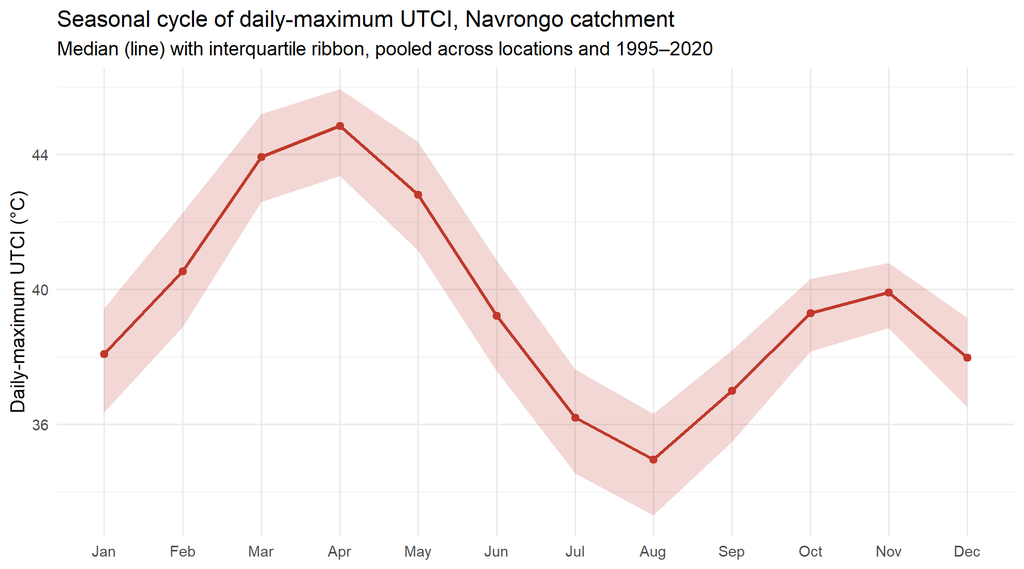

```r
monthly_dist <- daily_utci |>
  group_by(month) |>
  summarise(
    med = median(utci, na.rm = TRUE),
    lo  = quantile(utci, 0.25, na.rm = TRUE),
    hi  = quantile(utci, 0.75, na.rm = TRUE),
    .groups = "drop"
  )

ggplot(monthly_dist, aes(x = factor(month, levels = 1:12, labels = month.abb))) +
  geom_ribbon(aes(ymin = lo, ymax = hi, group = 1), alpha = 0.20, fill = "#C0392B") +
  geom_line(aes(y = med, group = 1), linewidth = 1, colour = "#C0392B") +
  geom_point(aes(y = med), size = 2, colour = "#C0392B") +
  labs(
    title = "Seasonal cycle of daily-maximum UTCI, Navrongo catchment",
    subtitle = "Median (line) with interquartile ribbon, pooled across locations and 1995–2020",
    x = NULL, y = "Daily-maximum UTCI (°C)"
  )
```

The series should rise to a March–May peak and fall to a July–August trough. A near-flat line across the year would indicate a problem with the exposure construction; a clear pre-monsoon hump confirms the Sahelian climatology.

## 2.2 Check 2 — Spatial pattern

Within a catchment of a few grid cells, the daily-max UTCI distribution should be nearly identical across locations. This check summarises each location’s long-run daily-max distribution and reports the spread *between* locations. Modest between-location variation is the expected and correct result; large scatter would indicate a coordinate or grid-matching fault.

```r
loc_dist <- daily_utci |>
  group_by(loc_id) |>
  summarise(
    loc_median = median(utci, na.rm = TRUE),
    loc_p90    = quantile(utci, 0.90, na.rm = TRUE),
    .groups = "drop"
  )

spatial_summary <- tibble(
  metric = c("locations",
             "between-location SD of the location-median (°C)",
             "range of location-medians (°C)",
             "between-location SD of the location-p90 (°C)",
             "range of location-p90 (°C)"),
  value = c(
    nrow(loc_dist),
    round(sd(loc_dist$loc_median, na.rm = TRUE), 3),
    round(diff(range(loc_dist$loc_median, na.rm = TRUE)), 2),
    round(sd(loc_dist$loc_p90, na.rm = TRUE), 3),
    round(diff(range(loc_dist$loc_p90, na.rm = TRUE)), 2)
  )
)
nice_table(spatial_summary,
           caption = "Between-location spread in the daily-max UTCI distribution. Small values are expected and correct for a single small catchment.")
```

Between-location spread in the daily-max UTCI distribution. Small values are expected and correct for a single small catchment.

| metric | value |
| --- | --- |
| locations | 904.000 |
| between-location SD of the location-median (°C) | 0.116 |
| range of location-medians (°C) | 0.860 |
| between-location SD of the location-p90 (°C) | 0.083 |
| range of location-p90 (°C) | 0.660 |

```r
spatial_sd <- sd(loc_dist$loc_median, na.rm = TRUE)
cat(sprintf("\nVerdict: %s\n",
            if (is.na(spatial_sd) || spatial_sd <= 1.0)
              "PASS — between-location variation is modest, as expected for a small catchment."
            else
              "CHECK — between-location variation is larger than expected; inspect coordinates and grid matching."))
```

```
#>
#> Verdict: PASS — between-location variation is modest, as expected for a small catchment.
```

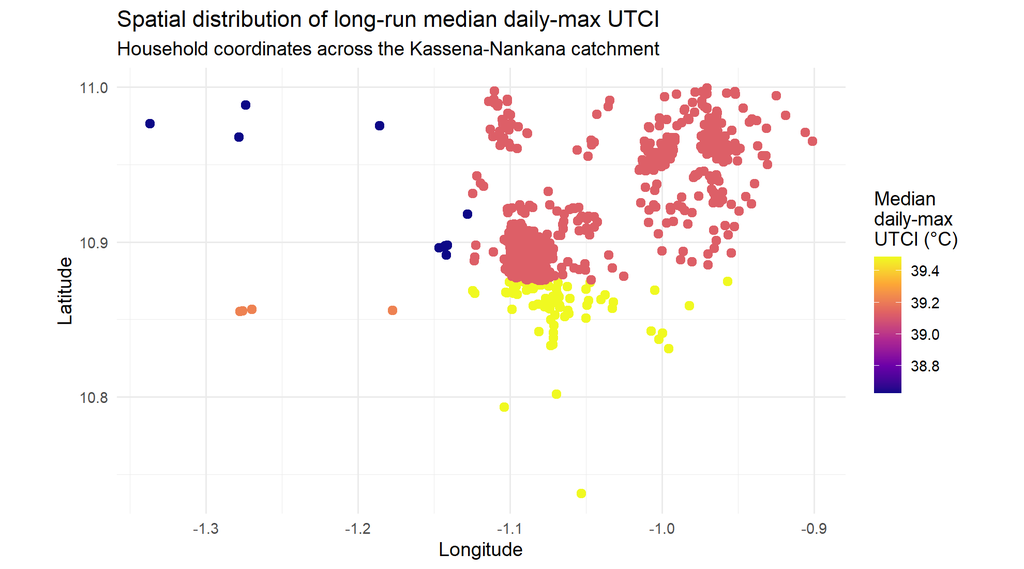

```r
# Map each location's long-run median daily-max UTCI. With all locations in a
# few grid cells, the map should look near-uniform in colour.
# Recover loc-level coordinates by reproducing the EXACT loc_id ordering used
# in 02_link_era5_utci.Rmd: distinct(lon, lat) |> arrange(lat, lon) |> row_number().
# (daily_utci carries loc_id, not coordinates; exposure carries coordinates.)
loc_xy <- exposure |>
  dplyr::select(lon, lat) |>
  distinct() |>
  arrange(lat, lon) |>
  mutate(loc_id = row_number())

loc_map <- loc_xy |> left_join(loc_dist, by = "loc_id")

ggplot(loc_map, aes(x = lon, y = lat, colour = loc_median)) +
  geom_point(size = 2.4) +
  scale_colour_viridis_c(option = "C", name = "Median\ndaily-max\nUTCI (°C)") +
  coord_quickmap() +
  labs(
    title = "Spatial distribution of long-run median daily-max UTCI",
    subtitle = "Household coordinates across the Kassena-Nankana catchment",
    x = "Longitude", y = "Latitude"
  )
```

The map should be close to uniform in colour, reflecting the limited within-catchment spatial variation at the 0.25° resolution of the ECMWF product. This is the empirical basis for the chapter’s statement that between-household exposure contrast is small and the temporal (daily, lagged) contrast is the dimension the DLNM exploits.

## 2.3 Check 3 — Year-on-year trend

The annual mean of daily-max UTCI should drift gently upward over 1995–2020, consistent with the regional warming signal, without abrupt steps that would signal a data-version or unit discontinuity.

```r
annual <- daily_utci |>
  filter(year >= 1995, year <= 2020) |>
  group_by(year) |>
  summarise(
    mean_max   = round(mean(utci, na.rm = TRUE), 2),
    median_max = round(median(utci, na.rm = TRUE), 2),
    .groups = "drop"
  )

# Simple linear trend in annual mean daily-max UTCI (°C per decade).
fit <- lm(mean_max ~ year, data = annual)
slope_per_decade <- round(unname(coef(fit)["year"]) * 10, 2)

nice_table(annual,
           caption = "Annual mean and median of daily-maximum UTCI (°C), 1995–2020.")
```

Annual mean and median of daily-maximum UTCI (°C), 1995–2020.

| year | mean_max | median_max |
| --- | --- | --- |
| 1,995 | 38.83 | 38.70 |
| 1,997 | 39.43 | 39.48 |
| 1,998 | 39.58 | 39.32 |
| 1,999 | 38.81 | 38.55 |
| 2,000 | 38.87 | 38.60 |
| 2,001 | 38.84 | 38.84 |
| 2,002 | 39.06 | 38.82 |
| 2,003 | 39.41 | 39.29 |
| 2,004 | 39.66 | 39.64 |
| 2,005 | 39.61 | 39.14 |
| 2,006 | 39.41 | 39.11 |
| 2,007 | 38.95 | 38.96 |
| 2,008 | 38.98 | 39.16 |
| 2,009 | 40.04 | 39.48 |
| 2,010 | 39.57 | 39.21 |
| 2,011 | 39.61 | 39.24 |
| 2,012 | 38.84 | 39.13 |
| 2,013 | 39.32 | 39.47 |
| 2,014 | 39.58 | 39.55 |
| 2,015 | 39.59 | 39.36 |
| 2,016 | 39.80 | 39.33 |
| 2,017 | 39.50 | 39.47 |
| 2,018 | 39.41 | 39.22 |
| 2,019 | 39.58 | 39.45 |
| 2,020 | 39.14 | 38.78 |

```r
cat(sprintf("\nLinear trend in annual mean daily-max UTCI: %+0.2f °C per decade\n",
            slope_per_decade))
```

```
#>
#> Linear trend in annual mean daily-max UTCI: +0.18 °C per decade
```

```r
cat(sprintf("Verdict: %s\n",
            if (!is.na(slope_per_decade) && slope_per_decade >= -0.5 && slope_per_decade <= 1.5)
              "PASS — gentle warming-consistent drift with no implausible jump."
            else
              "CHECK — annual trend is outside the expected gentle-warming range; inspect for a data-version discontinuity."))
```

```
#> Verdict: PASS — gentle warming-consistent drift with no implausible jump.
```

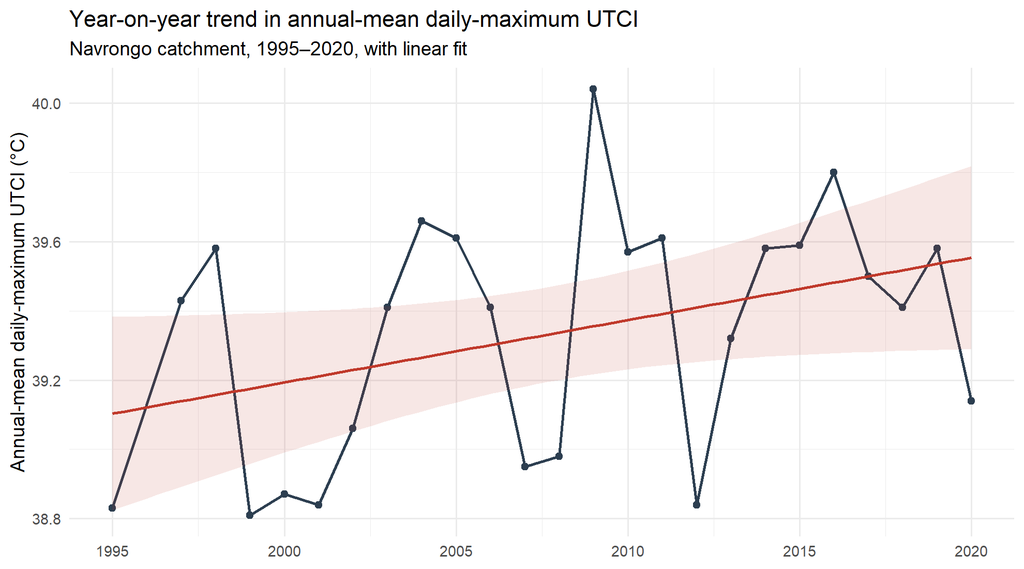

```r
ggplot(annual, aes(x = year, y = mean_max)) +
  geom_line(linewidth = 0.8, colour = "#2C3E50") +
  geom_point(size = 1.8, colour = "#2C3E50") +
  geom_smooth(method = "lm", se = TRUE, colour = "#C0392B",
              fill = "#C0392B", alpha = 0.12, linewidth = 0.8) +
  scale_x_continuous(breaks = seq(1995, 2020, 5)) +
  labs(
    title = "Year-on-year trend in annual-mean daily-maximum UTCI",
    subtitle = "Navrongo catchment, 1995–2020, with linear fit",
    x = NULL, y = "Annual-mean daily-maximum UTCI (°C)"
  )
```

A gentle positive slope is the expected signature of regional warming over the period; a flat or mildly positive trend is consistent and acceptable. What would warrant investigation is a sharp step between adjacent years, which would suggest a change in the underlying data product rather than a climatic signal.

## 2.4 Validation summary

```r
validation <- tibble(
  check = c("Seasonal pattern (hot-dry peak vs monsoon trough)",
            "Spatial pattern (between-location SD of median)",
            "Year-on-year trend (°C per decade)"),
  result = c(sprintf("amplitude %.1f °C", seasonal_amp),
             sprintf("%.3f °C", spatial_sd),
             sprintf("%+0.2f °C/decade", slope_per_decade)),
  verdict = c(
    if (seasonal_amp >= 4) "PASS" else "CHECK",
    if (!is.na(spatial_sd) && spatial_sd <= 1.0) "PASS" else "CHECK",
    if (!is.na(slope_per_decade) && slope_per_decade >= -0.5 &&
        slope_per_decade <= 1.5) "PASS" else "CHECK"
  )
)
nice_table(validation,
           caption = "Exposure-validation summary. All three checks should read PASS before the exposure feeds the Phase 3 DLNM.")
```

Exposure-validation summary. All three checks should read PASS before the exposure feeds the Phase 3 DLNM.

| check | result | verdict |
| --- | --- | --- |
| Seasonal pattern (hot-dry peak vs monsoon trough) | amplitude 9.8 °C | PASS |
| Spatial pattern (between-location SD of median) | 0.116 °C | PASS |
| Year-on-year trend (°C per decade) | +0.18 °C/decade | PASS |

If all three checks read PASS, the daily-maximum UTCI exposure is climatologically sound and `exposure.rds` is a trustworthy input to the Phase 3 distributed-lag model. If any reads CHECK, the corresponding section above should be inspected before proceeding.

# 3 Descriptive demography of the analytic cohort

The sections below scaffold the Phase 1 descriptive demography. They are intentionally outlined rather than completed here, because the outcome tabulations depend on the spine’s outcome and covariate fields, which are analysed alongside the outcome-modelling phases. The exposure-validation section above is the part of Phase 1 that is complete and load-bearing for the modelling that follows.

## 3.1 Cohort overview

```r
# Birth-year span and counts available from the exposure file (geocoded subset).
cohort <- exposure |>
  mutate(birth_year = lubridate::year(as.Date(child_dob)))

overview <- tibble(
  metric = c("pregnancies (geocoded, in window)",
             "unique mothers",
             "unique compounds (locationid)",
             "birth-year range"),
  value = c(
    format(nrow(cohort), big.mark = ","),
    format(dplyr::n_distinct(cohort$motherid), big.mark = ","),
    format(dplyr::n_distinct(cohort$locationid), big.mark = ","),
    sprintf("%d–%d", min(cohort$birth_year, na.rm = TRUE),
            max(cohort$birth_year, na.rm = TRUE))
  )
)
nice_table(overview, caption = "Analytic cohort overview (geocoded subset entering exposure linkage).")
```

Analytic cohort overview (geocoded subset entering exposure linkage).

| metric | value |
| --- | --- |
| pregnancies (geocoded, in window) | 2,696 |
| unique mothers | 1,641 |
| unique compounds (locationid) | 914 |
| birth-year range | 1995–2020 |

## 3.2 Outcome rates (to be completed with the full spine)

```r
# Placeholder. When this script is run against the full spine (not only the
# exposure file), compute annual and five-year-period rates of stillbirth,
# day-0, early-neonatal, neonatal, post-neonatal, infant, and under-five
# mortality, disaggregated by maternal education, SES quintile, residence,
# season of birth, and calendar period. These map to Objective 1 (§3.10.1).
```

## 3.3 Birth-weight distribution (to be completed with the full spine)

```r
# Placeholder. Summarise the birth-weight distribution and LBW prevalence for
# records with valid weights, disaggregated as above. Stream B (§3.10.5).
```